# PCA pre-batch del bloque tumoral GEO

TFM Melanoma Inmunoterapia

2026-05-05

# 1 Objetivo

Este documento realiza una exploración mediante **PCA pre-batch** del bloque tumoral de cohortes GEO integrado previamente.

El objetivo es visualizar la estructura global de los datos antes de aplicar cualquier corrección de batch effect, coloreando las muestras por:

- cohorte / dataset GEO,
- plataforma,
- respuesta binaria a inmunoterapia,
- y, si está disponible, tratamiento.

Este análisis permite evaluar si la principal fuente de variación está asociada a diferencias técnicas o de cohorte antes de realizar análisis posteriores como corrección de batch, análisis diferencial o modelos predictivos.

## 1.1 Ficha del informe

| Elemento | Detalle |
| --- | --- |
| Entrada | `integrated_dataset/se_integrated_geo_tumor.rds` |
| Salida | Scores PCA, varianza explicada y objeto `prcomp` en `resultados/pca_prebatch/` |
| Decision metodologica | Explorar la estructura de los datos antes de cualquier correccion |
| Visualizaciones clave | PCA por dataset, plataforma, respuesta binaria y tratamiento si existe |
| Uso posterior | Justificar la correccion de batch y comparar con el PCA post-batch |

# 2 Librerías

```r
required_packages <- c(
  "SummarizedExperiment",
  "dplyr",
  "ggplot2",
  "tibble",
  "knitr",
  "here"
)

missing_packages <- required_packages[!required_packages %in% rownames(installed.packages())]

if (length(missing_packages) > 0) {
  stop(
    "Faltan paquetes necesarios: ",
    paste(missing_packages, collapse = ", "),
    "\nInstálalos antes de compilar este documento."
  )
}

library(SummarizedExperiment)
library(dplyr)
library(ggplot2)
library(tibble)
library(knitr)
library(here)
```

# 3 Localización del objeto tumoral

Este Rmd intenta localizar automáticamente el objeto tumoral generado en la reconstrucción previa.  
Si tu archivo tiene otro nombre o está en otra carpeta, modifica manualmente `candidate_paths`.

```r
# Nombre esperado según el Rmd de reconstrucción v4:
# integrated_dataset/se_integrated_geo_tumor.rds

object_filename <- "se_integrated_geo_tumor.rds"

possible_roots <- unique(normalizePath(c(
  getwd(),
  file.path(getwd(), ".."),
  file.path(getwd(), "..", ".."),
  here::here(),
  "C:/Users/sonia/Desktop/2_TFM_MELANOMA"
), winslash = "/", mustWork = FALSE))

candidate_paths <- unique(c(
  file.path(possible_roots, "integrated_dataset", object_filename),
  file.path(possible_roots, "data", "processed", object_filename),
  file.path(possible_roots, "results", object_filename),
  file.path(possible_roots, "objects", object_filename),
  file.path(possible_roots, object_filename),
  object_filename
))

existing_paths <- candidate_paths[file.exists(candidate_paths)]

if (length(existing_paths) == 0) {
  recursive_hits <- unlist(lapply(possible_roots, function(root) {
    if (dir.exists(root)) {
      list.files(
        path = root,
        pattern = paste0("^", object_filename, "$"),
        recursive = TRUE,
        full.names = TRUE
      )
    } else {
      character(0)
    }
  }))
  existing_paths <- unique(recursive_hits[file.exists(recursive_hits)])
}

if (length(existing_paths) == 0) {
  diagnostic <- tibble::tibble(
    ruta_candidata = candidate_paths,
    existe = file.exists(candidate_paths)
  )
  print(diagnostic)
  stop(
    "No se ha encontrado el objeto tumoral .rds.\n",
    "El archivo esperado es: integrated_dataset/se_integrated_geo_tumor.rds\n",
    "Comprueba que el Rmd anterior generó ese archivo o actualiza candidate_paths."
  )
}

tumor_rds_path <- normalizePath(existing_paths[1], winslash = "/", mustWork = TRUE)
project_root <- normalizePath(file.path(dirname(tumor_rds_path), ".."), winslash = "/", mustWork = FALSE)
tumor_rds_path
```

```
## [1] "C:/Users/sonia/Desktop/2_TFM_MELANOMA/integrated_dataset/se_integrated_geo_tumor.rds"
```

```r
project_root
```

```
## [1] "C:/Users/sonia/Desktop/2_TFM_MELANOMA"
```

# 4 Carga del objeto tumoral

```r
se_tumor <- readRDS(tumor_rds_path)

se_tumor
```

```
## class: SummarizedExperiment
## dim: 200 170
## metadata(6): block_name datasets ... integration_method created_from
## assays(1): expr
## rownames(200): ABCF1 ADORA2A ... VCAN ZAP70
## rowData names(1): gene_symbol
## colnames(170): GSE78220__Pt1 GSE78220__Pt2 ... GSE211645__GSM6481993
##   GSE211645__GSM6481994
## colData names(16): sample_id patient_id ... prior_checkpoint_blockade
##   integrated_sample_id
```

# 5 Validaciones iniciales

```r
stopifnot(inherits(se_tumor, "SummarizedExperiment"))

assay_names <- assayNames(se_tumor)
assay_names
```

```
## [1] "expr"
```

```r
if ("expr" %in% assay_names) {
  assay_to_use <- "expr"
} else {
  assay_to_use <- assay_names[1]
  warning("No existe un assay llamado 'expr'. Se utilizará el primer assay disponible: ", assay_to_use)
}

expr <- assay(se_tumor, assay_to_use)
coldata <- as.data.frame(colData(se_tumor))

cat("Assay utilizado:", assay_to_use, "\n")
```

```
## Assay utilizado: expr
```

```r
cat("Número de genes:", nrow(expr), "\n")
```

```
## Número de genes: 200
```

```r
cat("Número de muestras:", ncol(expr), "\n")
```

```
## Número de muestras: 170
```

```r
cat("Número de filas en colData:", nrow(coldata), "\n")
```

```
## Número de filas en colData: 170
```

```r
stopifnot(ncol(expr) == nrow(coldata))

if (!identical(colnames(expr), rownames(coldata))) {
  warning("colnames(expr) y rownames(colData) no son idénticos. Se forzará sample_id a partir de colnames(expr).")
  rownames(coldata) <- colnames(expr)
}

stopifnot(identical(colnames(expr), rownames(coldata)))
```

# 6 Resumen del bloque tumoral

```r
summary_table <- tibble(
  elemento = c("Genes", "Muestras", "Assay utilizado", "Variables clínicas"),
  valor = c(nrow(expr), ncol(expr), assay_to_use, ncol(coldata))
)

kable(summary_table, caption = "Resumen general del objeto tumoral")
```

Resumen general del objeto tumoral

| elemento | valor |
| --- | --- |
| Genes | 200 |
| Muestras | 170 |
| Assay utilizado | expr |
| Variables clínicas | 16 |

## 6.1 Variables clínicas disponibles

```r
clinical_vars <- tibble(
  variable = colnames(coldata),
  n_no_na = sapply(coldata, function(x) sum(!is.na(x))),
  n_unique = sapply(coldata, function(x) length(unique(na.omit(x))))
)

kable(clinical_vars, caption = "Variables clínicas disponibles en colData")
```

Variables clínicas disponibles en colData

| variable | n_no_na | n_unique |
| --- | --- | --- |
| sample_id | 170 | 170 |
| patient_id | 170 | 170 |
| response_raw | 170 | 12 |
| response_binary | 129 | 2 |
| dataset | 170 | 3 |
| tissue | 170 | 1 |
| platform | 170 | 3 |
| original_sample_id | 170 | 170 |
| treatment | 145 | 6 |
| long_term_benefit | 86 | 2 |
| os_days | 105 | 101 |
| os_index | 105 | 2 |
| pfs_days | 105 | 98 |
| pfs_index | 105 | 2 |
| prior_checkpoint_blockade | 105 | 2 |
| integrated_sample_id | 170 | 170 |

# 7 Distribución de muestras

## 7.1 Por dataset

```r
if ("dataset" %in% colnames(coldata)) {
  tab_dataset <- as.data.frame(table(coldata$dataset, useNA = "ifany"))
  colnames(tab_dataset) <- c("dataset", "n_muestras")
  kable(tab_dataset, caption = "Distribución de muestras por dataset")
} else {
  cat("No existe la variable 'dataset' en colData.\n")
}
```

Distribución de muestras por dataset

| dataset | n_muestras |
| --- | --- |
| GSE211645 | 40 |
| GSE215868 | 105 |
| GSE78220 | 25 |

## 7.2 Por plataforma

```r
if ("platform" %in% colnames(coldata)) {
  tab_platform <- as.data.frame(table(coldata$platform, useNA = "ifany"))
  colnames(tab_platform) <- c("platform", "n_muestras")
  kable(tab_platform, caption = "Distribución de muestras por plataforma")
} else {
  cat("No existe la variable 'platform' en colData.\n")
}
```

Distribución de muestras por plataforma

| platform | n_muestras |
| --- | --- |
| GPL32584 | 40 |
| NanoString | 105 |
| RNA-seq | 25 |

## 7.3 Por respuesta binaria

```r
if ("response_binary" %in% colnames(coldata)) {
  tab_response <- as.data.frame(table(coldata$response_binary, useNA = "ifany"))
  colnames(tab_response) <- c("response_binary", "n_muestras")
  kable(tab_response, caption = "Distribución de muestras por respuesta binaria")
} else {
  cat("No existe la variable 'response_binary' en colData.\n")
}
```

Distribución de muestras por respuesta binaria

| response_binary | n_muestras |
| --- | --- |
| No_responder | 71 |
| Responder | 58 |
| NA | 41 |

## 7.4 Balance respuesta por dataset

```r
if (all(c("dataset", "response_binary") %in% colnames(coldata))) {
  tab_response_dataset <- as.data.frame(table(
    dataset = coldata$dataset,
    response_binary = coldata$response_binary,
    useNA = "ifany"
  ))
  kable(tab_response_dataset, caption = "Balance de respuesta binaria por dataset")
} else {
  cat("No están disponibles simultáneamente 'dataset' y 'response_binary'.\n")
}
```

Balance de respuesta binaria por dataset

| dataset | response_binary | Freq |
| --- | --- | --- |
| GSE211645 | No_responder | 0 |
| GSE215868 | No_responder | 59 |
| GSE78220 | No_responder | 12 |
| GSE211645 | Responder | 0 |
| GSE215868 | Responder | 45 |
| GSE78220 | Responder | 13 |
| GSE211645 | NA | 40 |
| GSE215868 | NA | 1 |
| GSE78220 | NA | 0 |

# 8 Preparación de la matriz para PCA

El PCA se calcula sobre las muestras, por lo que se transpone la matriz de expresión para que las filas sean muestras y las columnas genes.

Además, se filtran genes con varianza cero y, de forma opcional, se elimina el 25% de genes con menor varianza para reducir ruido.

```r
expr_mat <- as.matrix(expr)

# Comprobar valores no finitos
n_non_finite <- sum(!is.finite(expr_mat))
cat("Valores no finitos en la matriz de expresión:", n_non_finite, "\n")
```

```
## Valores no finitos en la matriz de expresión: 0
```

```r
if (n_non_finite > 0) {
  stop("La matriz de expresión contiene valores no finitos. Revisa NA, Inf o -Inf antes del PCA.")
}

# Genes con varianza > 0
gene_variance <- apply(expr_mat, 1, var, na.rm = TRUE)
summary(gene_variance)
```

```
##      Min.   1st Qu.    Median      Mean   3rd Qu.      Max.
##       2.1       6.1      31.7   48669.7     186.3 6405629.2
```

```r
expr_var <- expr_mat[gene_variance > 0, , drop = FALSE]
cat("Genes retenidos tras eliminar varianza cero:", nrow(expr_var), "\n")
```

```
## Genes retenidos tras eliminar varianza cero: 200
```

```r
# Filtro suave por varianza: conservar el 75% más variable
variance_cutoff <- quantile(gene_variance[gene_variance > 0], probs = 0.25, na.rm = TRUE)
expr_var_filtered <- expr_mat[gene_variance > variance_cutoff, , drop = FALSE]
cat("Genes retenidos tras filtro de varianza 25%:", nrow(expr_var_filtered), "\n")
```

```
## Genes retenidos tras filtro de varianza 25%: 150
```

```r
# Matriz final: muestras x genes
expr_pca <- t(expr_var_filtered)

stopifnot(nrow(expr_pca) == nrow(coldata))
```

# 9 Cálculo del PCA pre-batch

```r
pca <- prcomp(expr_pca, center = TRUE, scale. = TRUE)

var_exp <- (pca$sdev^2 / sum(pca$sdev^2)) * 100

pca_df <- as.data.frame(pca$x[, 1:5, drop = FALSE]) %>%
  rownames_to_column("sample_id_pca")

meta_df <- coldata %>%
  rownames_to_column("sample_id_pca")

pca_df <- left_join(pca_df, meta_df, by = "sample_id_pca")

head(pca_df)
```

|  | sample_id_pca | PC1 | PC2 | PC3 | PC4 | PC5 | sample_id | patient_id | response_raw | response_binary | dataset | tissue | platform | original_sample_id | treatment | long_term_benefit | os_days | os_index | pfs_days | pfs_index | prior_checkpoint_blockade | integrated_sample_id |
| --- | --- | --- | --- | --- | --- | --- | --- | --- | --- | --- | --- | --- | --- | --- | --- | --- | --- | --- | --- | --- | --- | --- |
| 1 | GSE78220__Pt1 | 8.487076 | 9.466540 | -4.005026 | 2.4815928 | -1.0064126 | Pt1 | Pt1 | Progressive Disease | No_responder | GSE78220 | Tumor | RNA-seq | Pt1 | NA | NA | NA | NA | NA | NA | NA | GSE78220__Pt1 |
| 2 | GSE78220__Pt2 | 13.989944 | 9.608128 | 5.294038 | 0.5584357 | 4.9113532 | Pt2 | Pt2 | Partial Response | Responder | GSE78220 | Tumor | RNA-seq | Pt2 | NA | NA | NA | NA | NA | NA | NA | GSE78220__Pt2 |
| 3 | GSE78220__Pt4 | 1.663132 | 5.674342 | -2.117804 | -3.1426283 | -0.4752436 | Pt4 | Pt4 | Partial Response | Responder | GSE78220 | Tumor | RNA-seq | Pt4 | NA | NA | NA | NA | NA | NA | NA | GSE78220__Pt4 |
| 4 | GSE78220__Pt5 | 1.267000 | 12.040614 | -3.852168 | -5.9483675 | 4.7192457 | Pt5 | Pt5 | Partial Response | Responder | GSE78220 | Tumor | RNA-seq | Pt5 | NA | NA | NA | NA | NA | NA | NA | GSE78220__Pt5 |
| 5 | GSE78220__Pt6 | 4.028945 | 10.427647 | -5.733492 | 1.2699018 | 1.5637188 | Pt6 | Pt6 | Partial Response | Responder | GSE78220 | Tumor | RNA-seq | Pt6 | NA | NA | NA | NA | NA | NA | NA | GSE78220__Pt6 |
| 6 | GSE78220__Pt7 | 2.375421 | 8.782470 | -3.308276 | -4.5894618 | 1.6437499 | Pt7 | Pt7 | Progressive Disease | No_responder | GSE78220 | Tumor | RNA-seq | Pt7 | NA | NA | NA | NA | NA | NA | NA | GSE78220__Pt7 |

## 9.1 Varianza explicada

```r
variance_table <- tibble(
  componente = paste0("PC", seq_along(var_exp)),
  varianza_explicada_pct = round(var_exp, 2),
  varianza_acumulada_pct = round(cumsum(var_exp), 2)
) %>%
  slice(1:10)

kable(variance_table, caption = "Porcentaje de varianza explicada por los primeros componentes principales")
```

Porcentaje de varianza explicada por los primeros componentes principales

| componente | varianza_explicada_pct | varianza_acumulada_pct |
| --- | --- | --- |
| PC1 | 35.47 | 35.47 |
| PC2 | 13.28 | 48.76 |
| PC3 | 9.42 | 58.17 |
| PC4 | 5.38 | 63.55 |
| PC5 | 3.86 | 67.41 |
| PC6 | 3.48 | 70.89 |
| PC7 | 3.17 | 74.05 |
| PC8 | 3.08 | 77.13 |
| PC9 | 2.44 | 79.58 |
| PC10 | 2.26 | 81.84 |

# 10 Función auxiliar de PCA

```r
plot_pca <- function(data, color_var, title_suffix) {
  if (!color_var %in% colnames(data)) {
    message("No existe la variable ", color_var, ". Se omite este gráfico.")
    return(NULL)
  }

  ggplot(data, aes(x = PC1, y = PC2, color = .data[[color_var]])) +
    geom_point(size = 3, alpha = 0.85) +
    labs(
      title = paste("PCA pre-batch tumoral -", title_suffix),
      x = paste0("PC1 (", round(var_exp[1], 1), "%)"),
      y = paste0("PC2 (", round(var_exp[2], 1), "%)"),
      color = color_var
    ) +
    theme_minimal(base_size = 13) +
    theme(
      plot.title = element_text(face = "bold"),
      legend.position = "right"
    )
}
```

# 11 PCA coloreado por dataset

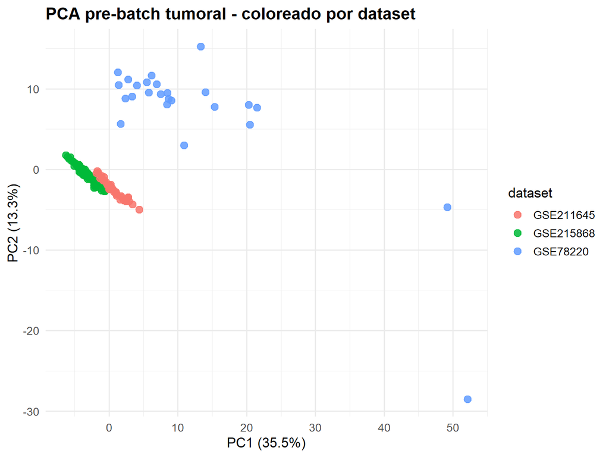

PCA pre-batch del bloque tumoral coloreado por dataset GEO.

```r
plot_pca(pca_df, "dataset", "coloreado por dataset")
```

# 12 PCA coloreado por plataforma

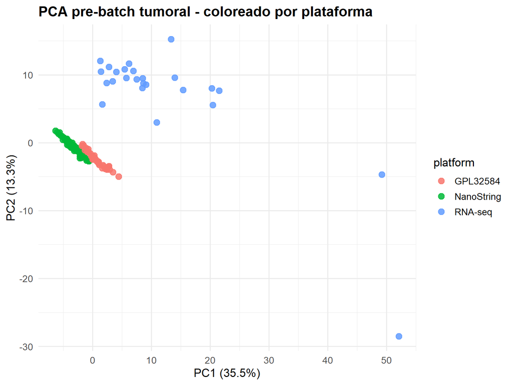

PCA pre-batch del bloque tumoral coloreado por plataforma.

```r
plot_pca(pca_df, "platform", "coloreado por plataforma")
```

# 13 PCA coloreado por respuesta binaria

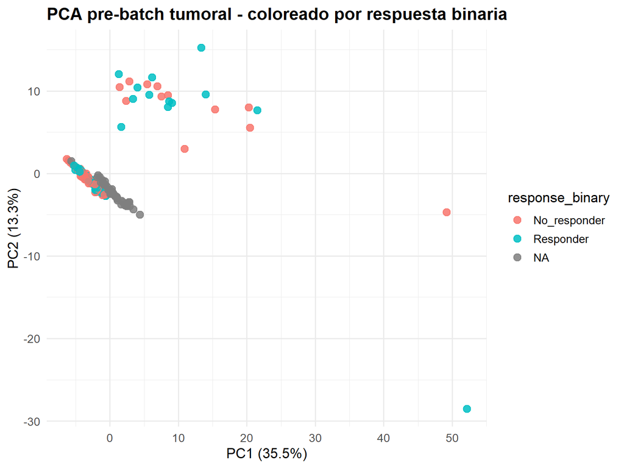

PCA pre-batch del bloque tumoral coloreado por respuesta binaria.

```r
plot_pca(pca_df, "response_binary", "coloreado por respuesta binaria")
```

# 14 PCA coloreado por tratamiento, si está disponible

[figure not shown]

```r
possible_treatment_vars <- c("treatment", "therapy", "treatment_type", "ici_type", "drug", "regimen")
existing_treatment_vars <- possible_treatment_vars[possible_treatment_vars %in% colnames(pca_df)]

if (length(existing_treatment_vars) > 0) {
  treatment_var <- existing_treatment_vars[1]
  plot_pca(pca_df, treatment_var, paste("coloreado por", treatment_var))
} else {
  cat("No se ha encontrado una variable clara de tratamiento entre:",
      paste(possible_treatment_vars, collapse = ", "), "\n")
}
```

# 15 PCA PC1 vs PC3

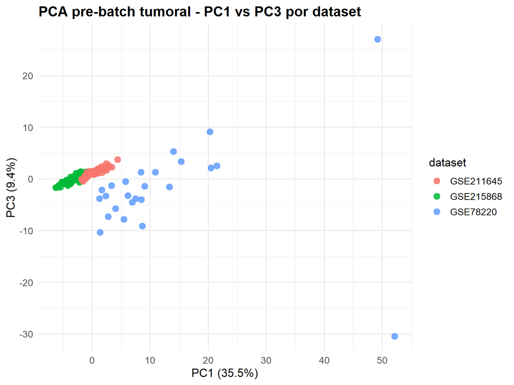

PCA pre-batch PC1 vs PC3 coloreado por dataset.

```r
if ("dataset" %in% colnames(pca_df)) {
  ggplot(pca_df, aes(x = PC1, y = PC3, color = dataset)) +
    geom_point(size = 3, alpha = 0.85) +
    labs(
      title = "PCA pre-batch tumoral - PC1 vs PC3 por dataset",
      x = paste0("PC1 (", round(var_exp[1], 1), "%)"),
      y = paste0("PC3 (", round(var_exp[3], 1), "%)"),
      color = "dataset"
    ) +
    theme_minimal(base_size = 13) +
    theme(plot.title = element_text(face = "bold"))
} else {
  cat("No existe la variable 'dataset'.\n")
}
```

# 16 Guardado de resultados del PCA

```r
output_dir <- file.path(project_root, "resultados", "pca_prebatch")
dir.create(output_dir, recursive = TRUE, showWarnings = FALSE)

pca_scores_path <- file.path(output_dir, "pca_prebatch_tumor_scores.csv")
variance_path <- file.path(output_dir, "pca_prebatch_tumor_variance_explained.csv")
pca_object_path <- file.path(output_dir, "pca_prebatch_tumor_prcomp.rds")

write.csv(pca_df, pca_scores_path, row.names = FALSE)
write.csv(variance_table, variance_path, row.names = FALSE)
saveRDS(pca, pca_object_path)

cat("Scores PCA guardados en:", pca_scores_path, "\n")
```

```
## Scores PCA guardados en: C:/Users/sonia/Desktop/2_TFM_MELANOMA/resultados/pca_prebatch/pca_prebatch_tumor_scores.csv
```

```r
cat("Varianza explicada guardada en:", variance_path, "\n")
```

```
## Varianza explicada guardada en: C:/Users/sonia/Desktop/2_TFM_MELANOMA/resultados/pca_prebatch/pca_prebatch_tumor_variance_explained.csv
```

```r
cat("Objeto prcomp guardado en:", pca_object_path, "\n")
```

```
## Objeto prcomp guardado en: C:/Users/sonia/Desktop/2_TFM_MELANOMA/resultados/pca_prebatch/pca_prebatch_tumor_prcomp.rds
```

# 17 Checklist final

```r
checklist <- tibble(
  comprobacion = c(
    "Objeto cargado como SummarizedExperiment",
    "Assay seleccionado correctamente",
    "Número de muestras en expr coincide con colData",
    "Nombres de muestras alineados",
    "Genes con varianza cero eliminados",
    "PCA calculado correctamente",
    "Resultados PCA guardados"
  ),
  estado = c(
    inherits(se_tumor, "SummarizedExperiment"),
    assay_to_use %in% assayNames(se_tumor),
    ncol(expr) == nrow(coldata),
    identical(colnames(expr), rownames(coldata)),
    nrow(expr_var) <= nrow(expr_mat),
    exists("pca") && inherits(pca, "prcomp"),
    file.exists(pca_scores_path) && file.exists(variance_path) && file.exists(pca_object_path)
  )
)

kable(checklist, caption = "Checklist final del análisis PCA pre-batch")
```

Checklist final del análisis PCA pre-batch

| comprobacion | estado |
| --- | --- |
| Objeto cargado como SummarizedExperiment | TRUE |
| Assay seleccionado correctamente | TRUE |
| Número de muestras en expr coincide con colData | TRUE |
| Nombres de muestras alineados | TRUE |
| Genes con varianza cero eliminados | TRUE |
| PCA calculado correctamente | TRUE |
| Resultados PCA guardados | TRUE |

# 18 Conclusión metodológica

Este documento genera el PCA pre-batch del bloque tumoral de GEO antes de aplicar cualquier corrección de batch effect.

La interpretación esperada es la siguiente:

- Si las muestras se agrupan principalmente por `dataset` o `platform`, esto sugiere la presencia de batch effect asociado a cohorte o tecnología.
- Si la separación por `response_binary` es menor que la separación por cohorte/plataforma, esto refuerza la necesidad de corregir o ajustar por batch antes de análisis diferencial o modelos predictivos.
- Este análisis justifica metodológicamente el siguiente paso: aplicar una estrategia de corrección de batch effect y comparar el PCA antes y después de dicha corrección.